## Outbreak curves: Southern Border States

[interactive chart not shown]

Source: Own estimation based on oficial Mexican Government data Dirección General de Epidemiología.

Southern border states

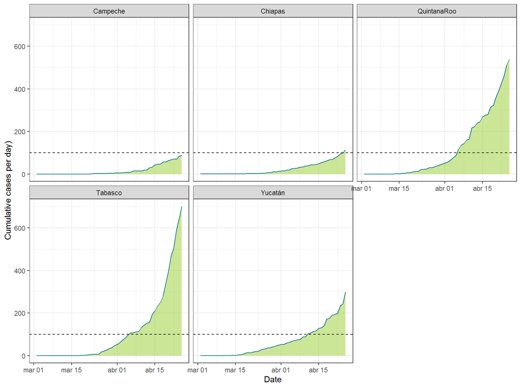

Source: Own estimation based on Dirección General de Epidemiología, oficial Mexican Government data.

### Covid19 confirmed cases.

**Interactive Map: Activate the US-Mexico Border, Sonora, Arizona, or World layer below, to display data accordingly**

[interactive chart not shown]

Source: Own estimation based on datos abiertos.Dirección General de Epidemiología, oficial Mexican Government data. World and USA data compiled by Chennai, Tamil Nadu, India. Novel Corona Virus 2019 Dataset.Note: Daily Updated data.

Data source Warning: There are important differences in the number of cases reported by health authorities, particularly between the state level and the federal Goverment sources. The latter providing lower figures. See for example [Sonora](https://www.facebook.com/secretaria.saludsonora/videos/1309163162613295/) state, which is reportig 88 cases for 13/04/2020, while the [oficial](https://www.gob.mx/salud/documentos/coronavirus-covid-19-comunicado-tecnico-diario-238449) data base reports 72 cases for the same date.

```r
#Source: https://www.gob.mx/salud/documentos/datos-abiertos-152127


## Indicadores posibles velocidad de complicaciones. (fecha_ingreso-fecha_def)
## periodo de ageresividad. fecha_sintomas-fecha_def
```